# 3_Tucker_decomposition_and_applications (1)

```python
%load_ext autoreload
%autoreload 2
%matplotlib inline
```

```python
import numpy as np
import matplotlib.pyplot as plt
from hottbox.core import Tensor, TensorTKD
from hottbox.algorithms.decomposition import HOSVD, HOOI
from hottbox.utils.generation import residual_tensor
from coursework.data import get_image, plot_tensors
```

```python
np.random.seed(0)
```

Return to Table of Contents

# Tucker Decomposition

[figure not shown]

In previous assignment, you have been provided materials which cover efficient representations of mutlidimensional arrays of data, such as the Tucker form. In this module, you will take a closer look at it and the assiciated computational methods.

Any tensor of arbitrarily large order can be decomposed in the Tucker form. As illustrated above, a tensor $\mathbf{\underline{X}} \in \mathbb{R}^{I \times J \times K}$ can be represented as a dense core tensor $\mathbf{\underline{G}}$ and a set of factor matrices $\mathbf{A} \in \mathbb{R}^{I \times Q}, \mathbf{B} \in \mathbb{R}^{J \times R}$ and $\mathbf{C} \in \mathbb{R}^{K \times P}$

$$ \mathbf{\underline{X}} = \mathbf{\underline{G}} \times_1 \mathbf{A} \times_2 \mathbf{B} \times_3 \mathbf{C} = \Big[ \mathbf{\underline{G}} ; \mathbf{A}, \mathbf{B}, \mathbf{C} \Big] $$

On practice, there exist several computational methods to accomplish this all of which are combined into a Tucker Decomposition framework. The two most commonly used algorithms are:

1. Higher Order Singular Value Decomposition (HOSVD))
2. Higher Order Orthogonal Iteration (HOOI))

# Higher Order Singular Value Decomposition (HOSVD)

The HOSVD is a special case of the Tucker decomposition, in which all the factor matrices are constrained to be orthogonal. They are computed as truncated version of the left singular matrices of all possible mode-$n$ unfoldings of tensor $\mathbf{\underline{X}}$:

$$ \begin{aligned} \mathbf{X}_{(1)} &= \mathbf{U}_1 \mathbf{\Sigma}_1 \mathbf{V}_1^T \quad \rightarrow \quad \mathbf{A} = \mathbf{U}_1[1:R_1]\\ \mathbf{X}_{(2)} &= \mathbf{U}_2 \mathbf{\Sigma}_2 \mathbf{V}_2^T \quad \rightarrow \quad \mathbf{B} = \mathbf{U}_2[1:R_2] \\ \mathbf{X}_{(3)} &= \mathbf{U}_3 \mathbf{\Sigma}_3 \mathbf{V}_3^T \quad \rightarrow \quad \mathbf{C} = \mathbf{U}_3[1:R_3] \\ \end{aligned} $$

After factor matrices are obtained, the core tensor $\mathbf{\underline{G}}$ is computed as

$$ \mathbf{\underline{G}} = \mathbf{\underline{X}} \times_1 \mathbf{A}^T \times_2 \mathbf{B}^T \times_3 \mathbf{C}^T $$

# Higher Order Orthogonal Iteration (HOOI)

HOOI algorithm is another special case of the Tuker decomposition. Like HOSVD, it decomposes a tensor into a dense core tensor and orthogonal factor matrices. The difference between the two lies in the fact that in HOOI the factor matrices are optimized iteratively using an Alternating Least Squares (ALS) approach. In other words, the tucker representation $[ \mathbf{\underline{G}};\mathbf{A}^{(1)}, \mathbf{A}^{(2)}, \cdots,\mathbf{A}^{(N)} ]$ of the given tensor $\mathbf{\underline{X}}$ is obtained through the HOOI as follows

$$ \begin{aligned} &\mathbf{\underline{Y}} = \mathbf{\underline{X}} \times_1 \mathbf{A}^{(1)T} \times_2 \cdots \times_{n-1} \mathbf{A}^{(n-1)T} \times_{n+1} \mathbf{A}^{(n+1)} \times \cdots \times_N \mathbf{A}^{(N)} \\ &\mathbf{A}^{(n)} \leftarrow R_n \text{ leftmost singular vectors of } \mathbf{Y}_{(n)} \end{aligned} $$

The above is repeated until convergence, then the core tensor $\mathbf{\underline{G}} \in \mathbb{R}^{R_1 \times R_2 \times \cdots \times R_N}$ is computed as

$$ \mathbf{\underline{G}} = \mathbf{\underline{X}} \times_1 \mathbf{A}^{(1)T} \times_2 \mathbf{A}^{(2)T} \times_3 \cdots \times_N \mathbf{A}^{(N)T} $$

# Multi-linear rank

The **multi-linear rank** of a tensor $\mathbf{\underline{X}} \in \mathbb{R}^{I_1 \times \cdots \times I_N}$ is the $N$-tuple $(R_1, \dots, R_N)$ where each $R_n$ is the rank of the subspace spanned by mode-$n$ fibers, i.e. $R_n = \text{rank} \big( \mathbf{X}_{(n)} \big)$. Thus, for our order-$3$ tensor the multi-linear rank is $(R_1, R_2, R_3)$. Multi-linear rank provides flexibility in compression and approximation of the original tensor.

> **NOTE:** For a tensor of order $N$ the values $R_1, R_2, \dots , R_N$ are not necessarily the same, whereas, for matrices (tensors of order 2) the equality $R_1 = R_2$ always holds, where $R_1$ and $R_2$ are the matrix column rank and row rank respectively.

# Performing tensor decomposition

```python
# Create tensor
I, J, K = 5, 6, 7
array_3d = np.random.rand(I * J * K).reshape((I, J, K)).astype(float)
tensor = Tensor(array_3d)

# Initialise algorithm
algorithm = HOSVD()

# Perform decomposing for selected multi-linear rank
ml_rank = (4, 5, 6)
tensor_tkd = algorithm.decompose(tensor, ml_rank)

# Result preview
print(tensor_tkd)

print('\n\tFactor matrices')
for mode, fmat in enumerate(tensor_tkd.fmat):
    print('Mode-{} factor matrix is of shape {}'.format(mode, fmat.shape))

print('\n\tCore tensor')
print(tensor_tkd.core)
```

```
Tucker representation of a tensor with multi-linear rank=(4, 5, 6).
Factor matrices represent properties: ['mode-0', 'mode-1', 'mode-2']
With corresponding latent components described by (5, 6, 7) features respectively.

	Factor matrices
Mode-0 factor matrix is of shape (5, 4)
Mode-1 factor matrix is of shape (6, 5)
Mode-2 factor matrix is of shape (7, 6)

	Core tensor
This tensor is of order 3 and consists of 120 elements.
Sizes and names of its modes are (4, 5, 6) and ['mode-0', 'mode-1', 'mode-2'] respectively.
```

# Evaluation and reconstruction

Tucker representation of an original tensor is almost always an approximation, regardless of which algorithm has been employed for performing decomposition. Thus, relative error of approximation is commonly used in order to evaluate performance of computational methods, i.e. the ratio between a Frobenious norms of residual and original tensors.

```python
# Compute residual tensor
tensor_res = residual_tensor(tensor, tensor_tkd)

# Compute error of approximation
rel_error = tensor_res.frob_norm / tensor.frob_norm

print("Relative error of approximation = {}".format(rel_error))
```

```
Relative error of approximation = 0.21320264561618077
```

## **Assigment 1**

1. Create a tensor of order 4 with sizes of each mode being defined by prime numbers and obtain a Tucker representation using HOOI algorithm with multi-linear (4, 10, 6, 2). Then calculation ratio between the number of elements in the original tensor and its Tucker form.
2. For a tensor that consists of 1331 elements, which multi-linear rank guarantees a perfect reconstruction from its Tucker form and why. Is such choice reasonable for practical applications?

### Solution: Part 1

```python
# Create a tensor
I, J, K, L = 2, 3, 5, 7
array_4d = np.random.rand(I * J * K * L).reshape((I, J, K, L)).astype(float)
tensor_4d = Tensor(array_4d)
tensor_4d
```

```
This tensor is of order 4 and consists of 210 elements.
Sizes and names of its modes are (2, 3, 5, 7) and ['mode-0', 'mode-1', 'mode-2', 'mode-3'] respectively.
```

```python
# Perform decomposition
# Implement algorithm
algorithm = HOOI()

# Perform decomposing for selected multi-linear rank
ml_rank = (4, 10, 6, 2)
tensor_tkd = algorithm.decompose(tensor_4d, ml_rank)

# Result preview
print(tensor_tkd)

print('\n\tFactor matrices')
for mode, fmat in enumerate(tensor_tkd.fmat):
    print('Mode-{} factor matrix is of shape {}'.format(mode, fmat.shape))

print('\n\tCore tensor')
print(tensor_tkd.core)
```

```
Tucker representation of a tensor with multi-linear rank=(2, 3, 5, 2).
Factor matrices represent properties: ['mode-0', 'mode-1', 'mode-2', 'mode-3']
With corresponding latent components described by (2, 3, 5, 7) features respectively.

	Factor matrices
Mode-0 factor matrix is of shape (2, 2)
Mode-1 factor matrix is of shape (3, 3)
Mode-2 factor matrix is of shape (5, 5)
Mode-3 factor matrix is of shape (7, 2)

	Core tensor
This tensor is of order 4 and consists of 60 elements.
Sizes and names of its modes are (2, 3, 5, 2) and ['mode-0', 'mode-1', 'mode-2', 'mode-3'] respectively.
```

```python
# Print ratio
tensor_res = residual_tensor(tensor_4d, tensor_tkd)

# Compute error of approximation
rel_error = tensor_res.frob_norm / tensor_4d.frob_norm

print("Relative error of approximation = {}".format(rel_error))
# Compute calculation ratio between the number of elements in the original tensor and its Tucker form
print('Calculate ratio between the number of elements in the original tensor and its Tucker form:')
# The number of elements in the original tensor
print('\n 1) The number of elements in the original tensor: ',tensor_4d.size)
# The number of elements in the Tucker core tensor
print('\n 2) The number of elements in the Tucker core tensor: ',tensor_tkd.core.size)
# Ratio between original tensor and its Tucker core tensor
ratio_core = tensor_4d.size/tensor_tkd.core.size
print("\t Ratio of elements between original tensor and its Tucker core tensor = ",ratio_core)
# The number of elements in the Tucker factor matrices
num_factor = 0;
for mode,fmat in enumerate(tensor_tkd.fmat):
    num_factor += fmat.size
print('\n 3) The number of elements in the Tucker factor matrics: ',num_factor)
# Total elements
num_tot = num_factor+tensor_tkd.core.size
print('\n 4) The total number of elements in the Tucker form: ',num_tot)
# Ratio between original tensor and its Tucker form
ratio_elements = tensor_4d.size/num_tot
print("\t Ratio of elements between original tensor and its Tucker form = ",ratio_elements)
print('\n Therefore the Tucker form compress the original tensor by %f times', ratio_elements)
```

```
Relative error of approximation = 0.38871898964218055
Calculate ratio between the number of elements in the original tensor and its Tucker form:

 1) The number of elements in the original tensor:  210

 2) The number of elements in the Tucker core tensor:  60
	 Ratio of elements between original tensor and its Tucker core tensor =  3.5

 3) The number of elements in the Tucker factor matrics:  52

 4) The total number of elements in the Tucker form:  112
	 Ratio of elements between original tensor and its Tucker form =  1.875

 Therefore the Tucker form compress the original tensor by %f times 1.875
```

### Solution: Part 2

**Explanation:**

Because the tensor $\mathbf{X}$ consists of $1331$ elements, then the product of its dimensions should equal to $1331$. Then, we apply prime decomposition to $1331$, giving $1331 = 11 \times 11 \times 11$. Since the prime factorization contains $3$ numbers, the Tucker representation of $\mathbf{X}$ has the maximum tensor order as $3$. To achieve a perfect recconstruction of tensor $\mathbf{X}$ from Tucker form, the core tensor dimensions in each mode should be same as the original tensor. In other words, given the multi-linear rank of $\mathbf{X}$ as $(R_{1},R_{2},\dots,R_{N})$, then $R_{n} = rank(\mathbf{X}_{n}) = I_{n}$, where $I_{n}$ is the rank of the n-mode unfolding of $\mathbf{X}$.

In this section, the multi-linear rank with order $3$ holds, as $(R_{1},R_{2},R_{3})=(11,11,11)$. For order is 2, then the multi-linear rank is $(R_{1},R_{2})$, and $R_{1}\times R_{2} = 1331$. However, the $R_{1} = R_{2}$ should always holds, but there is no solution for the above two conditions. Therefore, the order $2$ is impossible. For order equal to $1$, the Tucker decomposition cannot be applied. Thus, only multi-linear rank $(R_{1},R_{2},R_{3})=(11,11,11)$ guarantees the perfect reconstruction from Tucker representation.

However, the above representation takes all values so that there is no compression of data and no dimension reduction. Therefore, the elements contained in the Tucker form will be much greater than the original tensor. As a result, it is not reasonable for practical applications.

# Application: Image compression

Color images can be naturally represented as a tensor of order three with the shape `(height x width x channels)` where channels are, for example, Red, Blue and Green (RGB)

[figure not shown]

By keeping its original structure, allows to apply methods from multi-linear analysis. For instance, we can employ algorithms for Tucker decompositions in order to commress oringinal informaiton by varying values of desired multi-linear rank.

```
# Get data in form of a Tensor
car = get_image(item="car", view="top")
tensor = Tensor(car)

# Initialise algorithm and preform decomposition
algorithm = HOSVD()
tensor_tkd = algorithm.decompose(tensor, rank=(25, 25, 3))

# Evaluate result
tensor_res = residual_tensor(tensor, tensor_tkd)
rel_error = tensor_res.frob_norm / tensor.frob_norm

print("Relative error of approximation = {}".format(rel_error))
```

When can also visually inspect image obtained by reconstructing the Tucker representation

```
# Reconstruction
tensor_rec = tensor_tkd.reconstruct()

# Plot original and reconstructed images side by side
plot_tensors(tensor, tensor_rec)
```

[figure not shown]

## **Assigment 2**

For this assignment you are provided with function `get_image()` which requires two parameters: `item` and `view`. The valid values for former are **car** and **apple**, while the latter takes only **side** and **top**.

1. Use multi-linear rank equal to `(50, 50, 2)` in order to obtain Tucker representations of images of the car and apple. Analyse results by visually inspecting their reconstructions.
2. Use multi-linear rank equal to `(50, 50, 2)` in order to obtain Tucker representations of images of the apple taken from the top and from the side. Analyse results by visually inspecting their reconstructions.
3. What would happen to the reconstruction if the value of multi-linear rank corresponding to the channel mode is decreased to 1.

### Solution: Part 1

```python
# Create tensors from images - Use top view
car = get_image(item="car", view="top")
tensor_car = Tensor(car)
apple = get_image(item="apple", view="top")
tensor_apple = Tensor(apple)
print('Tensor of car:\n')
print(tensor_car,'\n')
print('Tensor of apple:\n')
print(tensor_apple)
```

```
Tensor of car:

This tensor is of order 3 and consists of 49152 elements.
Sizes and names of its modes are (128, 128, 3) and ['mode-0', 'mode-1', 'mode-2'] respectively.

Tensor of apple:

This tensor is of order 3 and consists of 49152 elements.
Sizes and names of its modes are (128, 128, 3) and ['mode-0', 'mode-1', 'mode-2'] respectively.
```

```python
# Perform decomposition
# Initialise algorithm
algorithm = HOSVD()

# Perform decomposing for selected multi-linear rank
ml_rank = (50, 50, 2)

# Car tensor decomposition
tensor_tkd_car = algorithm.decompose(tensor_car, ml_rank)
# Apple tensor decomposition
tensor_tkd_apple = algorithm.decompose(tensor_apple, ml_rank)
```

```
Relative error of approximation for car = 0.049915778045715196
Relative error of approximation for apple = 0.04847145726539924
```

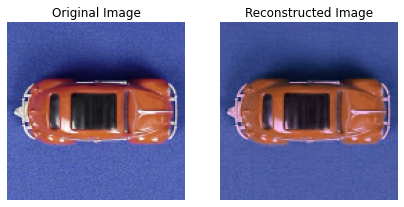

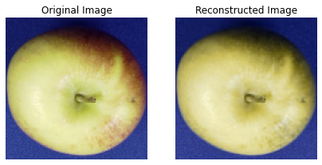

```python
# Evaluate results
# Car result
tensor_res_car = residual_tensor(tensor_car, tensor_tkd_car)
rel_error_car = tensor_res_car.frob_norm / tensor_car.frob_norm

print("Relative error of approximation for car = {}".format(rel_error_car))

# Car Reconstruction
tensor_rec_car = tensor_tkd_car.reconstruct()

# Plot original and reconstructed images side by side
plot_tensors(tensor_car, tensor_rec_car)

# Apple result
tensor_res_apple = residual_tensor(tensor_apple, tensor_tkd_apple)
rel_error_apple = tensor_res_apple.frob_norm / tensor_car.frob_norm

print("Relative error of approximation for apple = {}".format(rel_error_apple))

# Apple Reconstruction
tensor_rec_apple = tensor_tkd_apple.reconstruct()

# Plot original and reconstructed images side by side
plot_tensors(tensor_apple, tensor_rec_apple)
```

**Explanations:**

In conclusion, though the imperfect Tucker reconstruction will bring some errors in resolution, colours and approximation, most information about the image is maintained, and the image becomes much smaller. Consequently, the Tucker form can be used for image compression.

### Solution: Part 2

```python
# Create tensors from images
apple_top = get_image(item="apple", view="top")
tensor_top = Tensor(apple_top)
apple_side = get_image(item="apple", view="side")
tensor_side = Tensor(apple_side)
print('Tensor of apple top view:\n')
print(tensor_top,'\n')
print('Tensor of apple side view:\n')
print(tensor_side)
```

```
Tensor of apple top view:

This tensor is of order 3 and consists of 49152 elements.
Sizes and names of its modes are (128, 128, 3) and ['mode-0', 'mode-1', 'mode-2'] respectively.

Tensor of apple side view:

This tensor is of order 3 and consists of 49152 elements.
Sizes and names of its modes are (128, 128, 3) and ['mode-0', 'mode-1', 'mode-2'] respectively.
```

```python
# Perform decomposition
# Initialise algorithm
algorithm = HOSVD()

# Perform decomposing for selected multi-linear rank
ml_rank = (50, 50, 2)

# Car tensor decomposition
tensor_tkd_top = algorithm.decompose(tensor_top, ml_rank)
# Apple tensor decomposition
tensor_tkd_side = algorithm.decompose(tensor_side, ml_rank)
```

```
Relative error of approximation for apple top view = 0.037062258387408245
Relative error of approximation for apple side view = 0.06574690406026353
```

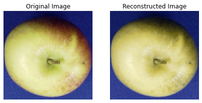

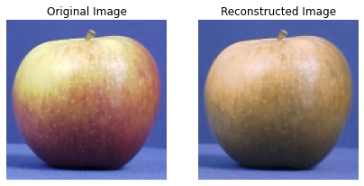

```python
# Evaluate results
# Top view result
tensor_res_top = residual_tensor(tensor_top, tensor_tkd_top)
rel_error_top = tensor_res_top.frob_norm / tensor_top.frob_norm

print("Relative error of approximation for apple top view = {}".format(rel_error_top))

# Top view Reconstruction
tensor_rec_top = tensor_tkd_top.reconstruct()

# Plot original and reconstructed images side by side
plot_tensors(tensor_top, tensor_rec_top)

# Side view result
tensor_res_side = residual_tensor(tensor_side, tensor_tkd_side)
rel_error_side = tensor_res_side.frob_norm / tensor_side.frob_norm

print("Relative error of approximation for apple side view = {}".format(rel_error_side))

# Apple Reconstruction
tensor_rec_side = tensor_tkd_side.reconstruct()

# Plot original and reconstructed images side by side
plot_tensors(tensor_side, tensor_rec_side)
```

**Explanations**

As discussed before, after Tucker decomposition with $(50, 50, 2)$, the images reconstruced will be more blurry with less elements contained, and the least significant colour channel will be removed leading colour difference in images.

From perspective of the top view, it is clear that the green and blue colours are dominant, therefore, the red channel will be removed, causing the reconstructed image will no red colour. However, for the side view image, the R, G, B are balanced. Therefore, the Tucker form will preserve two significant colours that are the combination of RGB, and discard the less important one. After removing one channel, the images maintain the dominant colour in the background as blue, along with the mix of green and red, leading to the brown colour in the resonstructed apple. The approximation error of top view ($3.7\%$) is smaller than the side view ($6.6\%$), which is due to the mix of colours. Therefore, the more balance of colour between RGB, the more approximation error in the reconstructed image.

### Solution: Part 3

**Explanations**

If the multi-linear rank related to the channel mode is decreased to $1$, then only the colour that minimize the approximation error will be adopted by the Tucker form. In other words, only the most dominant colour will be preserved, and the image will be more like the grey image but is acutally expressed by the colour with most percentages of high intensity. If the image is balance with all colours occupy similar percentage of intensity, then the resulted color will be the mix of all colours. The approximation error will be larger than reconstructed one with $2$ channel modes, and the balance image will have larger error than the unbalanced one.

The example images are illustrated below. Since green is the dominant colour in the top view of apple, the result image is in green-scale. But for the side view, the colours are balanced. Therefore, the reconstructed image mix these colours, leading to a more grey-scale result. The approximation errors are $16.73\%$ and $22.51\%$ for top view and side view, respectively, which agree with our conclusion.

```
Tensor of apple top view:

This tensor is of order 3 and consists of 49152 elements.
Sizes and names of its modes are (128, 128, 3) and ['mode-0', 'mode-1', 'mode-2'] respectively.

Tensor of apple side view:

This tensor is of order 3 and consists of 49152 elements.
Sizes and names of its modes are (128, 128, 3) and ['mode-0', 'mode-1', 'mode-2'] respectively.
Relative error of approximation for apple top view = 0.1672796297390355
Relative error of approximation for apple side view = 0.2251191410550059
```

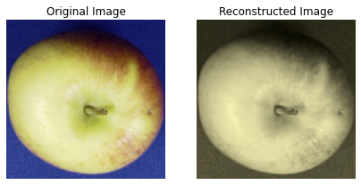

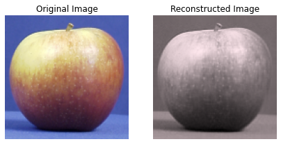

```python
# Create tensors from images
apple_top = get_image(item="apple", view="top")
tensor_top = Tensor(apple_top)
apple_side = get_image(item="apple", view="side")
tensor_side = Tensor(apple_side)
print('Tensor of apple top view:\n')
print(tensor_top,'\n')
print('Tensor of apple side view:\n')
print(tensor_side)
# Perform decomposition
# Initialise algorithm
algorithm = HOSVD()

# Perform decomposing for selected multi-linear rank
ml_rank = (50, 50, 1)

# Car tensor decomposition
tensor_tkd_top = algorithm.decompose(tensor_top, ml_rank)
# Apple tensor decomposition
tensor_tkd_side = algorithm.decompose(tensor_side, ml_rank)

# Evaluate results
# Top view result
tensor_res_top = residual_tensor(tensor_top, tensor_tkd_top)
rel_error_top = tensor_res_top.frob_norm / tensor_top.frob_norm

print("Relative error of approximation for apple top view = {}".format(rel_error_top))

# Top view Reconstruction
tensor_rec_top = tensor_tkd_top.reconstruct()

# Plot original and reconstructed images side by side
plot_tensors(tensor_top, tensor_rec_top)

# Side view result
tensor_res_side = residual_tensor(tensor_side, tensor_tkd_side)
rel_error_side = tensor_res_side.frob_norm / tensor_side.frob_norm

print("Relative error of approximation for apple side view = {}".format(rel_error_side))

# Apple Reconstruction
tensor_rec_side = tensor_tkd_side.reconstruct()

# Plot original and reconstructed images side by side
plot_tensors(tensor_side, tensor_rec_side)
```